[figure not shown]

Отчет по лабораторной работе №8

Операционные системы

Никитенко Арина Александровна

Российский университет дружбы народов, Москва, Россия

1/22

[figure not shown]

Информация

[figure not shown]

Докладчик

Никитенко Арина Александровна

2/22

[figure not shown]

Докладчик

Никитенко Арина Александровна

НКАбд-07-25, Студенческий билет: 1132250435

2/22

[figure not shown]

Докладчик

Никитенко Арина Александровна

НКАбд-07-25, Студенческий билет: 1132250435

Российский университет дружбы народов

2/22

[figure not shown]

Цель работы

Ознакомится с инструментами поиска файлов и фильтрации текстовых

данных. Приобрести практические навыки: по управлению процессами (и

заданиями), по проверке использования диска и обслуживанию файловых

систем

3/22

[figure not shown]

Выполнение лабораторной работы

4/22

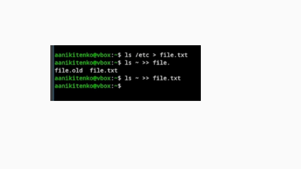

1.1 Запишем в файл file.txt названия файлов, содержащихся в каталоге /etc.

Допишем в этот же файл названия файлов, содержащихся в домашнем

каталоге.

Рисунок 1: 1.1

5/22

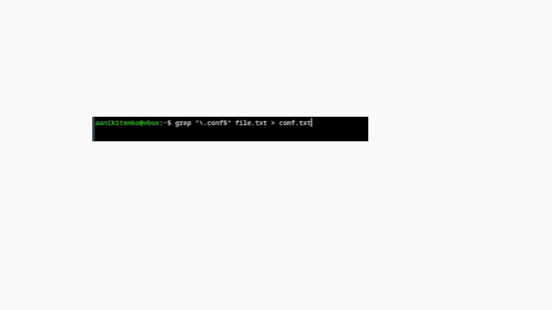

1.2 Поиск файлов с расширением .conf и запишем в conf.txt

Рисунок 2: Результат сохраняется в conf.txt

6/22

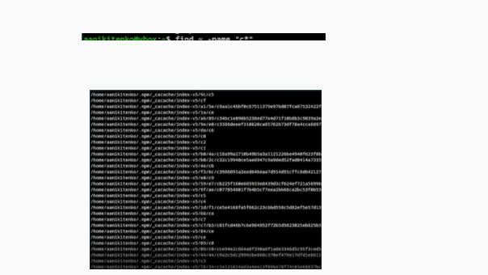

1.3 Поиск файлов в домашнем каталоге,начинающихся с с

Рисунок 3: Вариант поиска 1

7/22

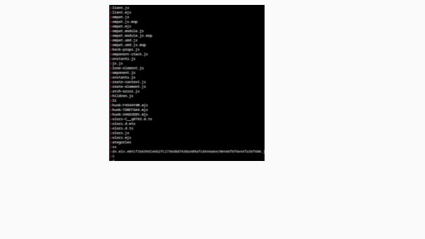

8/22

Рисунок 5: Вариант поиска 2(ls -R ~ | grep «^c»)

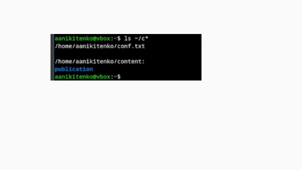

Рисунок 6: Вариант поиска 3(ls ~/c*)

9/22

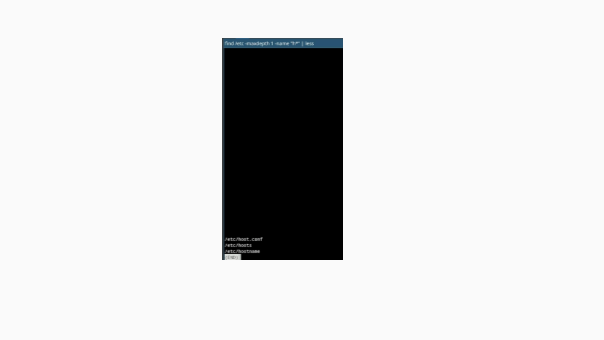

1.4 Постраничный вывод файлов из /etc , начинающихся с h

10/22

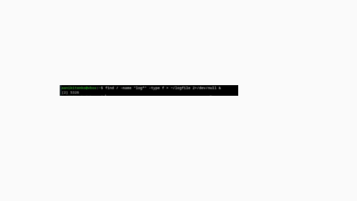

1.5 Запуск в фоновом режиме записи файлов с именем,начинающимся на

log в ~/logfile

Рисунок 8: 1.5

11/22

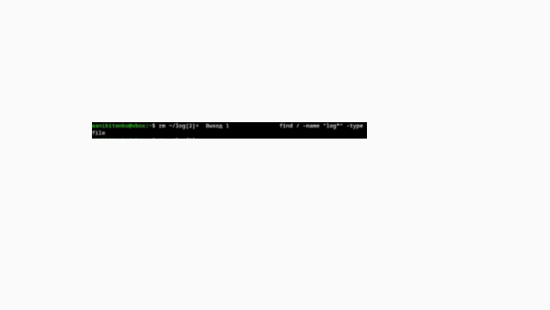

1.6 Удаление файла ~/logfile

Рисунок 9: rm ~/logfile

12/22

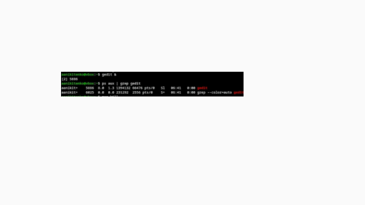

1.7 Запуск gedit в фоновом режиме и определение PID процесса gedit

Рисунок 10: gedit & , ps aux | grep gedit

13/22

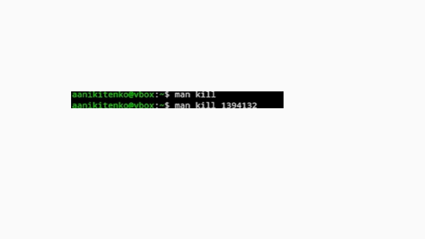

Рисунок 11: 1.8

14/22

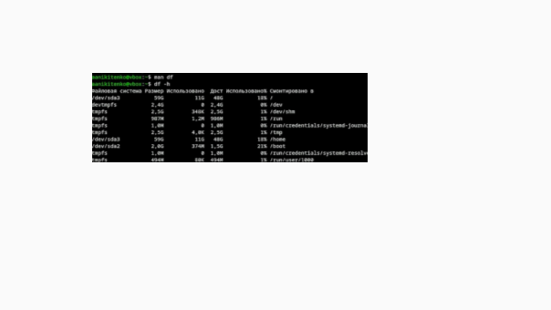

1.9 Команда df

Рисунок 12: df

15/22

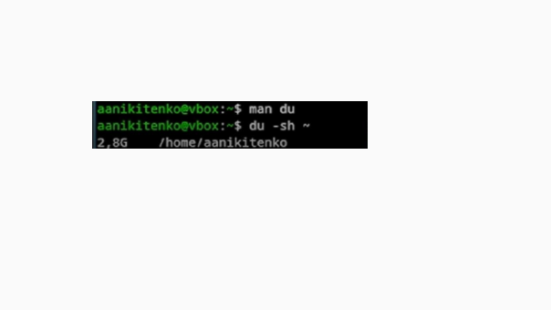

1.10 Команда du

Рисунок 13: du

16/22

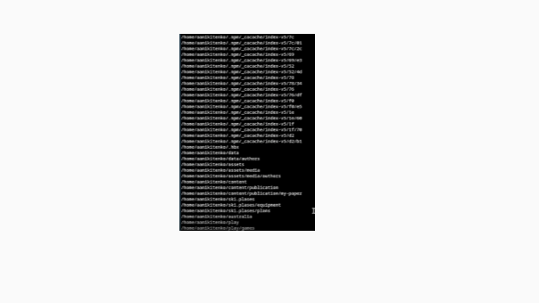

1.11 Вывод имён всех директорий в домашнем каталоге

17/22

Вывод

Мы ознакомились с инструментами поиска файлов и фильтрации

текстовых данных. Также мы приобрели практические навыки: по

управлению процессами (и заданиями), по проверке использования диска

и обслуживанию файловых систем

18/22

Контрольные вопросы

1

Какие потоки ввода-вывода вы знаете? В Linux существует три

стандартных потока ввода-вывода: stdin (0) — стандартный ввод

(обычно клавиатура), stdout (1) — стандартный вывод (обычно экран),

stderr (2) — стандартный вывод ошибок (обычно экран).

19/22

[figure not shown]

Контрольные вопросы

1

Какие потоки ввода-вывода вы знаете? В Linux существует три

стандартных потока ввода-вывода: stdin (0) — стандартный ввод

(обычно клавиатура), stdout (1) — стандартный вывод (обычно экран),

stderr (2) — стандартный вывод ошибок (обычно экран).

2

Объясните разницу между операцией > и ». Операция > выполняет

перенаправление с перезаписью файла (создает новый файл или

перезаписывает существующий), а операция » выполняет

перенаправление с добавлением (дописывает данные в конец файла,

не удаляя существующее содержимое).

19/22

[figure not shown]

Контрольные вопросы

1

Какие потоки ввода-вывода вы знаете? В Linux существует три

стандартных потока ввода-вывода: stdin (0) — стандартный ввод

(обычно клавиатура), stdout (1) — стандартный вывод (обычно экран),

stderr (2) — стандартный вывод ошибок (обычно экран).

2

Объясните разницу между операцией > и ». Операция > выполняет

перенаправление с перезаписью файла (создает новый файл или

перезаписывает существующий), а операция » выполняет

перенаправление с добавлением (дописывает данные в конец файла,

не удаляя существующее содержимое).

3

Что такое конвейер? Конвейер (|) — это механизм, передающий вывод

одной команды на ввод другой, что позволяет создавать цепочки

обработки данных, например: cat file.txt | grep «ошибка» | less.

19/22

[figure not shown]

Контрольные вопросы

1

Какие потоки ввода-вывода вы знаете? В Linux существует три

стандартных потока ввода-вывода: stdin (0) — стандартный ввод

(обычно клавиатура), stdout (1) — стандартный вывод (обычно экран),

stderr (2) — стандартный вывод ошибок (обычно экран).

2

Объясните разницу между операцией > и ». Операция > выполняет

перенаправление с перезаписью файла (создает новый файл или

перезаписывает существующий), а операция » выполняет

перенаправление с добавлением (дописывает данные в конец файла,

не удаляя существующее содержимое).

3

Что такое конвейер? Конвейер (|) — это механизм, передающий вывод

одной команды на ввод другой, что позволяет создавать цепочки

обработки данных, например: cat file.txt | grep «ошибка» | less.

4

Что такое процесс? Чем это понятие отличается от программы?

19/22

5

Что такое PID и GID? PID — это уникальный числовой идентификатор

процесса, а GID — идентификатор группы процесса или реальный

идентификатор группы пользователя.

20/22

[figure not shown]

5

6

Что такое PID и GID? PID — это уникальный числовой идентификатор

процесса, а GID — идентификатор группы процесса или реальный

идентификатор группы пользователя.

Что такое задачи и какая команда позволяет ими управлять? Задачи —

это процессы, запущенные внутри текущей сессии терминала.

Управляет ими команда jobs, а также комбинации клавиш Ctrl+Z

(приостановить), fg (вернуть на передний план), bg (запустить в фоне)

и символ & для запуска программы сразу в фоне.

20/22

[figure not shown]

5

6

Что такое PID и GID? PID — это уникальный числовой идентификатор

процесса, а GID — идентификатор группы процесса или реальный

идентификатор группы пользователя.

Что такое задачи и какая команда позволяет ими управлять? Задачи —

это процессы, запущенные внутри текущей сессии терминала.

Управляет ими команда jobs, а также комбинации клавиш Ctrl+Z

(приостановить), fg (вернуть на передний план), bg (запустить в фоне)

и символ & для запуска программы сразу в фоне.

7

Найдите информацию об утилитах top и htop. Каковы их функции?

Утилита top — это стандартный интерактивный диспетчер задач,

показывающий список процессов, загрузку CPU, памяти и swap в

реальном времени, а htop — это улучшенная версия top с цветным

интерфейсом, возможностью прокрутки, управлением мышью и более

удобным завершением процессов.

20/22

8

Назовите и дайте характеристику команде поиска файлов. Приведите

примеры использования этой команды. Команда поиска файлов — find,

которая рекурсивно обходит каталоги и ищет файлы по условиям (имя,

размер, дата, права доступа). Примеры использования: find /home

-name “*.txt” (найти все txt-файлы в home), find . -type f -size +100M

(найти файлы больше 100 Мб в текущей папке), find /var/log -mtime -1

(файлы, измененные за последние 24 часа).

21/22

[figure not shown]

8

Назовите и дайте характеристику команде поиска файлов. Приведите

примеры использования этой команды. Команда поиска файлов — find,

которая рекурсивно обходит каталоги и ищет файлы по условиям (имя,

размер, дата, права доступа). Примеры использования: find /home

-name “*.txt” (найти все txt-файлы в home), find . -type f -size +100M

(найти файлы больше 100 Мб в текущей папке), find /var/log -mtime -1

(файлы, измененные за последние 24 часа).

9

Можно ли по контексту (содержанию) найти файл? Если да, то как? Да,

файл можно найти по контексту (содержанию) с помощью команды

grep: например, grep -r «искомый текст» /путь/к/каталогу или find .

-name “*.py” -exec grep «import os» {} .

21/22

[figure not shown]

8

Назовите и дайте характеристику команде поиска файлов. Приведите

примеры использования этой команды. Команда поиска файлов — find,

которая рекурсивно обходит каталоги и ищет файлы по условиям (имя,

размер, дата, права доступа). Примеры использования: find /home

-name “*.txt” (найти все txt-файлы в home), find . -type f -size +100M

(найти файлы больше 100 Мб в текущей папке), find /var/log -mtime -1

(файлы, измененные за последние 24 часа).

9

Можно ли по контексту (содержанию) найти файл? Если да, то как? Да,

файл можно найти по контексту (содержанию) с помощью команды

grep: например, grep -r «искомый текст» /путь/к/каталогу или find .

-name “*.py” -exec grep «import os» {} .

10

Как определить объем свободной памяти на жёстком диске? Объем

свободной памяти на жестком диске определяется командой df -h (в

человекочитаемом виде) или df -i (для проверки свободных инодов).

21/22

11

Как определить объем вашего домашнего каталога? Объем домашнего

каталога определяется командой du -sh ~ (общий размер) или du -h ~

–max-depth=1 (размер каждой папки внутри).

22/22

[figure not shown]

11

12

Как определить объем вашего домашнего каталога? Объем домашнего

каталога определяется командой du -sh ~ (общий размер) или du -h ~

–max-depth=1 (размер каждой папки внутри).

Как удалить зависший процесс? Чтобы удалить зависший процесс,

нужно сначала найти его PID командами ps aux | grep «имя_процесса»,

pgrep -l «имя» или через top/htop, а затем отправить сигнал на

завершение: kill PID (сигнал SIGTERM — вежливая просьба

завершиться) или kill -9 PID (сигнал SIGKILL — принудительное

убийство процессом ядра), также можно использовать killall -9

имя_процесса или в htop нажать F9, выбрать SIGKILL и нажать Enter.

22/22